# gc-tcd_example

## Analysis of an Unknown Mixture via Gas Chromatrography

Al Fischer  
January 2, 2020

**Download a Template on [GitHub](https://raw.githubusercontent.com/alphonse/alphonse.github.io/master/devel/chem370/notebooks/gc-tcd/gc-tcd_template.ipynb):**

# Introduction

- What the sample is
- The instrument you are using:
  - The separation technique
  - The detector type
  - The polarity of the column.
- The purpose of the analysis (what you hope the instrument/data will tell you)

*Note: The answers to these questions should be worked into a written narrative with additional detail for full credit. You should not just provide a list of answers to these questions!*

# Materials and Methods

- The sample
  - Where did it come from?
  - What did you do to prepare it for analysis?
  - How was the sample introduced into the instrument?
  - How much sample did you use?
- The instrument
  - What is the technique being used?
  - What is the make and model of the instrument being used?
  - What are the specific parameters (column type, carrier gas, etc.) of the instrument used.
  - Any other details you deem relevant/necessary to repeat the work exactly.
  - You may use the blank instrument table below as a template to include (replace 'XXXXX' with the values you look up).

*Note: The answers to these questions should be worked into a written narrative with additional detail for full credit. You should not just provide a list of answers to these questions!*

*Note 2: Some of this may be prepared ahead of time, but some of it MUST BE COMPLETED IN LAB. For example, if you are weighing quantities of a substance or dispensing exact volumes they need to go in this notebook. This notebook should be an EXACT record of what you did in lab, just like a paper notebook!*

| Table 1: | GC Parameters |
| --- | --- |
| **Make and Model** | Gow-Mac XXXXX |
| **Column Type** | 8' x 1/8", 20% DC-200 on 30/80 Chromosorp P (Gow-Mac) |
| **Injector Temp (deg. C)** | XXXXX |
| **Column Temp (deg. C)** | XXXXX |
| **Detector Temp (deg. C)** | XXXXX |
| **Detector Attenuation** | 1 |
| **Detector** | XXXXX |
| **Carrier Gas** | Nitrogen |
| **Carrier Flow Rate (ml/min)** | 50 ml/min |
| **Data Acquisition (DAQ)** | Vernier Instrumentation Amplifier, $\pm$20 mV range |
| **Software** | Vernier Logger Lite |

# Results & Data Analysis

## Define Functions (obtained from Chem 370 Lab Manual)

This first section is used to define all functions that will be needed for data processing. These functions were copy and pasted from the Chem 370 Lab Manual.

For this analysis, the only function needed is `peakArea()` used to calculate the area under a curve.

```matlab
#####   peakArea   #################################################################################

##      returns area under curve (integrates peak) for 2-column matrix X from x1 to x2
##      where X(:, 1) is x data and X(:, 2) is y data,
##      x1 is the lower limit, and x2 is the upper limit of integration.
##      Also plots result for inspection if p = true.
##      Usage:
##      peakArea([chromatogram(:, "TIME COLUMN"), chromatogram(:, "Signal Column")], 1.7, 2.05)
##
##      (c) 2020 Al Fischer for Chem 370 Lab CC-BY-SA
#####################################################################################################

function a = peakArea(C, x1, x2, p = true)
    x = C((C(:,1) > x1 & C(:,1) < x2), 1);
    y = C((C(:,1) > x1 & C(:,1) < x2), 2);
    a = trapz(x, y);
    if p == true
        plot(C(:, 1), C(:, 2));
        hold on
        area(x,y);
        xlabel("Time");
        ylabel("Signal (arbitrary units)")
        hold off
        disp(["Peak Area = ", num2str(a)])
    end
end
```

## Import the Data and Pre-process

The data were saved in CSV format with `Time (min)` in column 1 and `Signal (mV)` in column 2. The first step is to import the data to Octave from CSV:

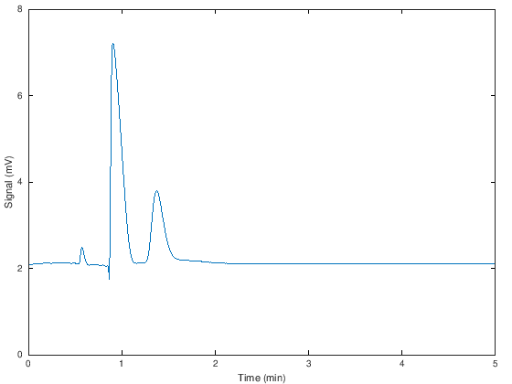

```matlab
##### import the data

chromatogram = csvread("data/gc-tcd_data.csv"); ## import the data
plot(chromatogram(:, 1), chromatogram(:, 2));   ## plot the data to see what it looks like
xlabel("Time (min)"); ylabel("Signal (mV)");    ## add axis labels
```

Note that there is a baseline offset in the data. This should be removed by subtrating the mean baseline value. I will use the mean value from 4-5 minutes as the "baseline" value. This baseline is just a result of the 0 setting on the GC, so it's OK to remove it after the fact.

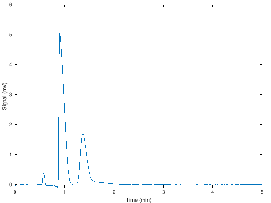

```matlab
##### correct the baseline offset

## Define the "baseline" as 4 minutes to end of chromatogram where there are no peaks
baseline = mean(chromatogram(481:end, 2));

## subtract the mean baseline value and store in second column of data set
chromatogram(:, 2) = chromatogram(:, 2) .- baseline;

## replot data with baseline removed
plot(chromatogram(:, 1), chromatogram(:, 2));   ## plot the data to see what it looks like
xlabel("Time (min)"); ylabel("Signal (mV)");    ## add axis labels
ylim([-0.1 6]);
```

To get the percent composition, each peak in the chromatogram must be integrated. This will be done with the `peakArea()` function for both peaks in the chromatogram.

```
Peak Area = 0.62247
```

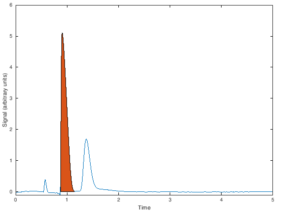

```matlab
##### calculate the peak area for first peak

peak1_area = peakArea([chromatogram(:, 1), chromatogram(:, 2)], 0.87, 1.15, true);
ylim([-0.1 6]);
```

```
Peak Area = 0.28093
```

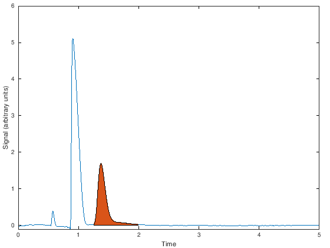

```matlab
##### calculate the peak area for second peak

peak2_area = peakArea([chromatogram(:, 1), chromatogram(:, 2)], 1.25, 2.0, true);
ylim([-0.1 6]);
```

```matlab
##### Calculate Percent Composition

peak1_percent = peak1_area / (peak1_area + peak2_area)*100
peak2_percent = peak2_area / (peak1_area + peak2_area)*100
```

```
peak1_percent =  68.903
peak2_percent =  31.097
```

Overall, the sample was found to be composed of **69% compound 1** (`peak1_percent`) and **31% compound 2** (`peak2_percent`).

## Estimating S/N

where $H$ is the peak height and $h$ is the peak-to-peak baseline noise.

```matlab
##### Determine H, the peak heights, and h, the noise

## find standard deviation of baseline, from 4 minutes to end where there are no peaks
h = 2 * (max(chromatogram(481:end, 2)) - min(chromatogram(481:end, 2)))
% H1 = max(chromatogram(:, 2)(chromatogram(:, 1) > 0 & < 1.3)); # H for tallest peak will be the maximum value in the chromatogram.
H1 = max(chromatogram(chromatogram(:, 1) < 1.3, 2)) # 1.3 represents dividing line between the two peaks in minutes.
H2 = max(chromatogram(chromatogram(:, 1) > 1.3, 2)) # 1.3 represents dividing line between the two peaks in minutes.
```

```
h =  0.027339
H1 =  5.1130
H2 =  1.6951
```

```matlab
##### Calculate S/N for each peak

sn_peak1 = H1/h
sn_peak2 = H2/h
```

```
sn_peak1 =  187.02
sn_peak2 =  62.002
```

The signal-to-noise ratio for **peak 1 was 187** and for **peak 2 was 62**.

# Conclusion